# Cam Report

Lyron Winderbaum

9 August 2017

## The Data

Here I’ll go through a little dataset I collected in which the subjects are cams. Below is an image of a cam in use – a size 6 Black Diamond Camalot C4, to be precise. A cam is a device mostly used in recreational rockclimbing that can be manipulated to have a variety of different widths and hence be placed into cracks of different sizes.

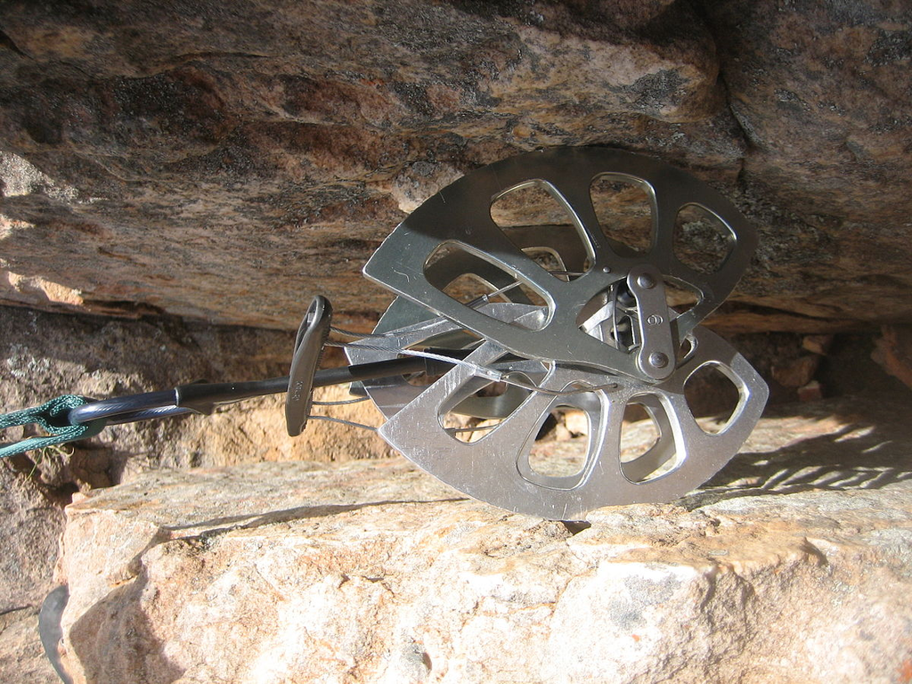

A #6 Black Diamond Camalot C4 placed in a crack (image taken from [wikipedia](https://en.wikipedia.org/wiki/Camalot)).

There are several differernt brands that manufacture cams, and some of them provide useful charts such as the one below.

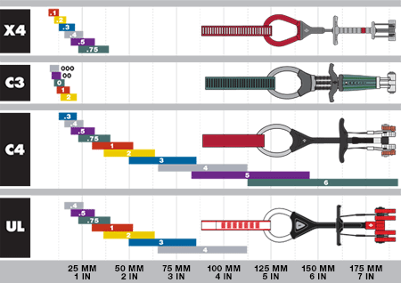

A cam comparison chart taken from [the black diamond website](http://blackdiamondequipment.com/en/climbing-cams-stoppers-nuts-hexes/camalottm-BD262104_cfg.html)).

Now this chart is great, but not all brands provide such a nice figure, and nobody provides a nice figure comparing different brands, or organising it differently to put similar sized cams next to each other, or looking at other factors like weight, etc. So I decided to go around to each of the brands websites and collect all the technical specifications and curate them into as single dataset, so that I could:

- Figure out how to make weird plots like this, which show a range, using ggplot2 — something I thought was pretty interesting.
- Make other, more useful plots comparing different brands and placing cams of similar sizes next to each other so they can more easily be compared.

So I did that, collected technical specifcations for 196 cams from four different brands:

```r
cam_df = read.csv('cam_df.csv', stringsAsFactors = FALSE)
head(cam_df)
```

```
##   Brand Variety NoCams Size Colour Weight Strength  Min  Max
## 1    BD      C3      3  000   grey     55        4  7.8 12.9
## 2    BD      C3      3   00 purple     57        6  9.0 13.7
## 3    BD      C3      3    0  green     59        7 10.7 15.8
## 4    BD      C3      3    1    red     62       10 12.0 18.8
## 5    BD      C3      3    2 yellow     66       10 14.2 22.6
## 6    BD      X4      4  0.1    red     51        5  8.4 13.8
```

Note that the values in the **Colour** column correspond to the colours as reported in the technical specifcations, which when given to ggplot2 as strings are interpreted as colours, but not neccessarily colours that actually look much like the colours of the cams themselves, so I’ll make a few replacements to better match the look of the actual colours.

```r
# Fluro green and lighter grey look bad
cam_df[cam_df$Colour == "green",        "Colour"] = "darkgreen"
cam_df[cam_df$Colour == "grey",         "Colour"] = "darkgrey"

# Metolius `light blue', `dark blue' and `light purple'
cam_df[cam_df$Colour == "light blue",   "Colour"] = "skyblue"
cam_df[cam_df$Colour == "light purple", "Colour"] = "orchid"
cam_df[cam_df$Colour == "dark blue",    "Colour"] = "darkblue"

# DMM `silver' (very dark grey)
cam_df[cam_df$Colour == "silver",       "Colour"] = "grey50"
```

For convenience I’ll also create a unique identifier column by combining the **Brand**, **Variety** and **Size** columns.

```r
cam_df$ID = paste(cam_df$Brand, cam_df$Variety, cam_df$Size)
```

## Plots

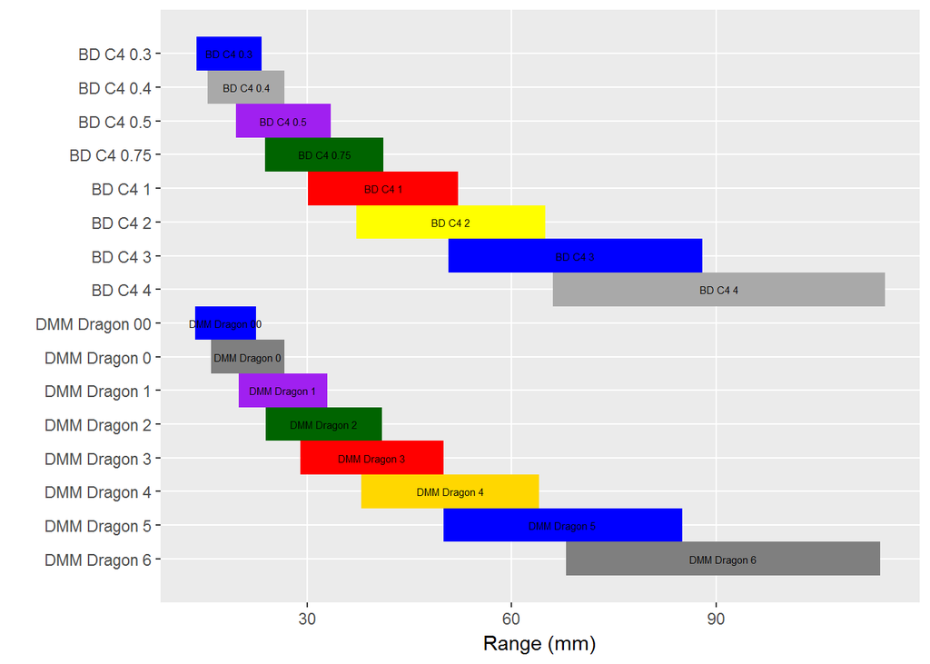

```r
# Compare C4s with corresponding sized Dragons
cam_subset = subset(cam_df, Variety %in% c('C4', 'Dragon'))
# Remove the two biggest C4 cams as they are bigger than the biggest Dragon Cams
cam_subset = subset(cam_subset, !((Variety == 'C4') & (Size %in% c('5', '6'))))
# Sort factor values neatly.
cam_subset = cam_subset[order(cam_subset$Brand, cam_subset$Min), ]

# using annotate()
n = nrow(cam_subset)
p <- ggplot()
p <- p + annotate("rect", xmin = (n - 0.5):0.5, xmax = (n + 0.5):1.5,
                  ymin = cam_subset$Min, ymax = cam_subset$Max,
                  alpha = 1, fill = cam_subset$Colour)
p <- p + annotate("text", x = n:1, y = (cam_subset$Min + cam_subset$Max) / 2,
                  label = cam_subset$ID, size = 2)
p <- p + scale_x_continuous(name = '', breaks = 1:n,
                            labels = rev(cam_subset$ID))
p <- p + scale_y_continuous(name = "Range (mm)")
p <- p + theme(panel.grid.minor = element_blank())
p <- p + coord_flip()
print(p)
```

Nice. This is a comparison of DMM Dragon cams to BD Camalots, in the sizes in which they have comparable cams. But now that we have it in a data frame we can reorganise this to make a better plot:

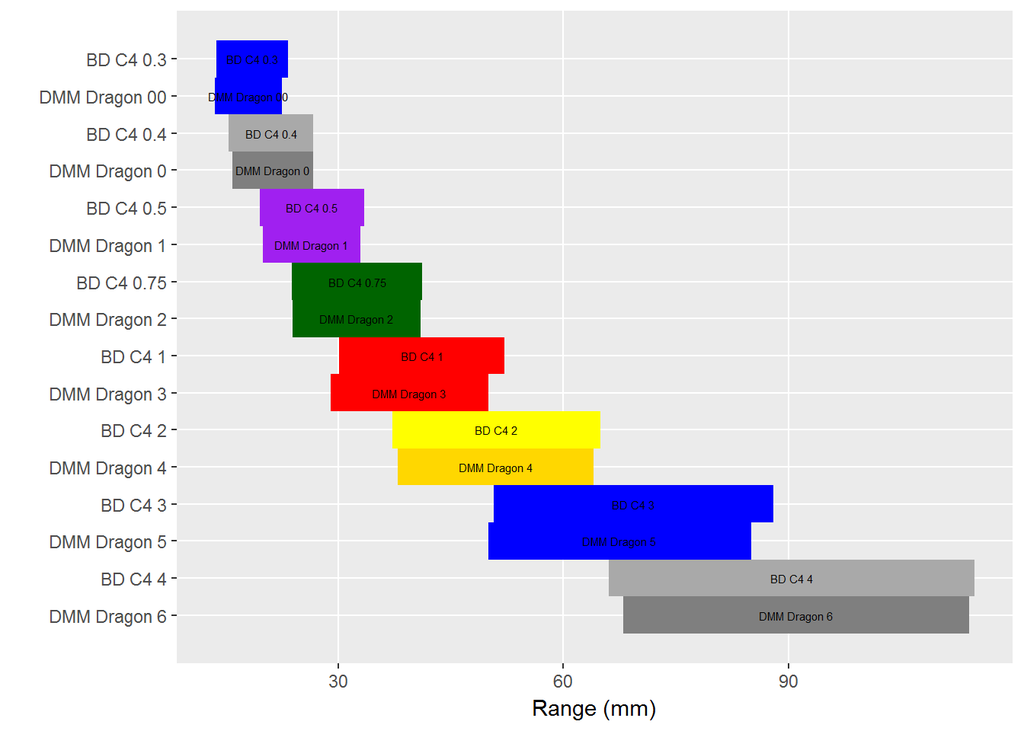

```r
# Sort factor values better.
tmp.order = ceiling((1:n)/2)
tmp.order[seq(2, n, 2)] = ((n / 2) + 1):n
cam_subset = cam_subset[tmp.order, ]

# using annotate()
n = nrow(cam_subset)
p <- ggplot()
p <- p + annotate("rect", xmin = (n - 0.5):0.5, xmax = (n + 0.5):1.5,
                  ymin = cam_subset$Min, ymax = cam_subset$Max,
                  alpha = 1, fill = cam_subset$Colour)
p <- p + annotate("text", x = n:1, y = (cam_subset$Min + cam_subset$Max) / 2,
                  label = cam_subset$ID, size = 2)
p <- p + scale_x_continuous(name = '', breaks = 1:n,
                            labels = rev(cam_subset$ID))
p <- p + scale_y_continuous(name = "Range (mm)")
p <- p + theme(panel.grid.minor = element_blank())
p <- p + coord_flip()
print(p)
```

and we could plot weight on the y-axis, instead of ID:

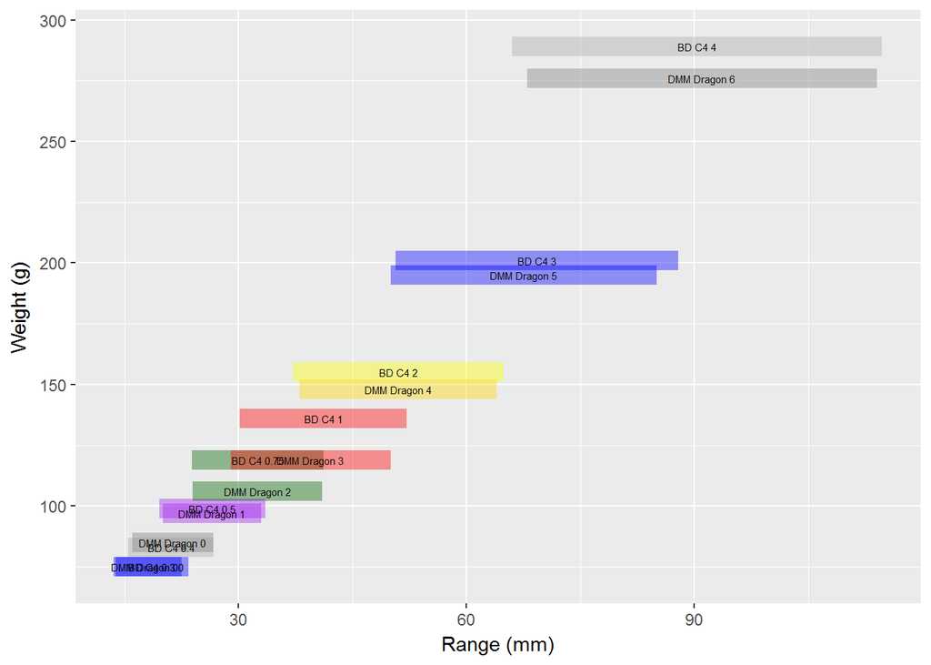

```r
# using annotate()
n = nrow(cam_subset)
p <- ggplot()
p <- p + annotate("rect", xmin = cam_subset$Weight - 4,
                  xmax = cam_subset$Weight + 4,
                  ymin = cam_subset$Min, ymax = cam_subset$Max,
                  alpha = 0.4, fill = cam_subset$Colour)
p <- p + annotate("text", x = cam_subset$Weight,
                  y = (cam_subset$Min + cam_subset$Max) / 2,
                  label = cam_subset$ID, size = 2)
p <- p + scale_x_continuous(name = 'Weight (g)')
p <- p + scale_y_continuous(name = "Range (mm)")
p <- p + coord_flip()
print(p)
```

we could zoom in a little and do a plot of all the cams in certain size range:

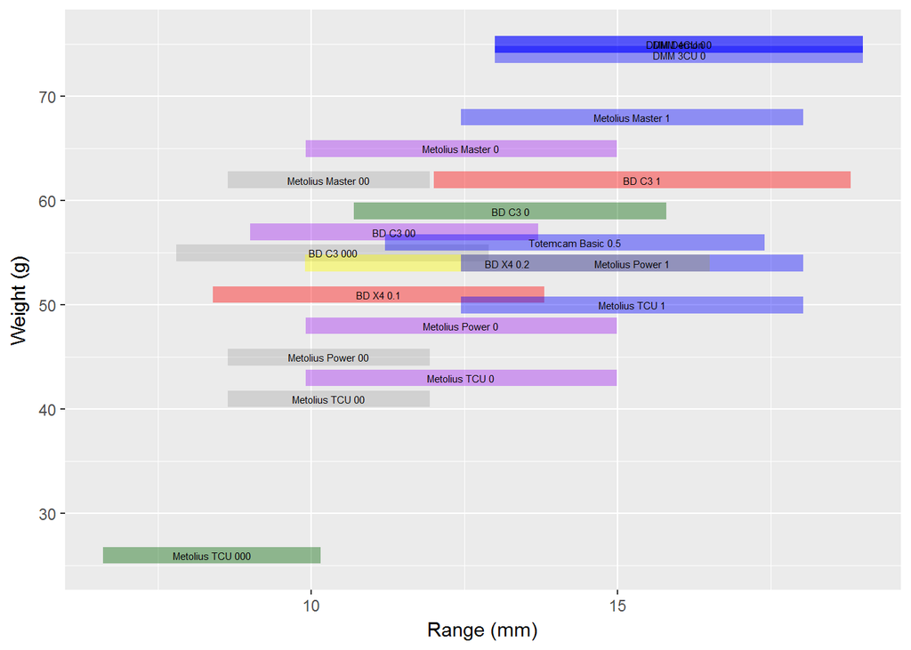

```r
cam_subset = subset(cam_df, Max < 20)
# using annotate()
n = nrow(cam_subset)
p <- ggplot()
p <- p + annotate("rect", xmin = cam_subset$Weight - 0.8,
                  xmax = cam_subset$Weight + 0.8,
                  ymin = cam_subset$Min, ymax = cam_subset$Max,
                  alpha = 0.4, fill = cam_subset$Colour)
p <- p + annotate("text", x = cam_subset$Weight,
                  y = (cam_subset$Min + cam_subset$Max) / 2,
                  label = cam_subset$ID, size = 2)
p <- p + scale_x_continuous(name = 'Weight (g)')
p <- p + scale_y_continuous(name = "Range (mm)")
p <- p + coord_flip()
print(p)
```

## Colophon

This report was written in [Rmarkdown](http://rmarkdown.rstudio.com/) using [RStudio](https://www.rstudio.com/products/rstudio/). Markdown is a simple formatting syntax for authoring HTML, PDF, and MS Word documents. [knitr](https://yihui.name/knitr/) and [pandoc](http://pandoc.org/) converted the raw Rmarkdown to html. This colophon was modelled after that of the book [R packages](http://r-pkgs.had.co.nz/).

```
##  setting  value
##  version  R version 3.4.0 (2017-04-21)
##  system   x86_64, mingw32
##  ui       RTerm
##  language (EN)
##  collate  English_Australia.1252
##  tz       Australia/Adelaide
##  date     2017-08-16
```

```
## Packages -----------------------------------------------------------------
```

```
##  package    * version date       source
##  backports    1.1.0   2017-05-22 CRAN (R 3.4.0)
##  base       * 3.4.0   2017-04-21 local
##  colorspace   1.3-2   2016-12-14 CRAN (R 3.4.0)
##  compiler     3.4.0   2017-04-21 local
##  datasets   * 3.4.0   2017-04-21 local
##  devtools     1.13.2  2017-06-02 CRAN (R 3.4.0)
##  digest       0.6.12  2017-01-27 CRAN (R 3.4.0)
##  evaluate     0.10.1  2017-06-24 CRAN (R 3.4.0)
##  ggplot2    * 2.2.1   2016-12-30 CRAN (R 3.4.0)
##  graphics   * 3.4.0   2017-04-21 local
##  grDevices  * 3.4.0   2017-04-21 local
##  grid         3.4.0   2017-04-21 local
##  gtable       0.2.0   2016-02-26 CRAN (R 3.4.0)
##  htmltools    0.3.6   2017-04-28 CRAN (R 3.4.0)
##  knitr        1.16    2017-05-18 CRAN (R 3.4.0)
##  labeling     0.3     2014-08-23 CRAN (R 3.4.0)
##  lazyeval     0.2.0   2016-06-12 CRAN (R 3.4.0)
##  magrittr     1.5     2014-11-22 CRAN (R 3.4.0)
##  memoise      1.1.0   2017-04-21 CRAN (R 3.4.0)
##  methods    * 3.4.0   2017-04-21 local
##  munsell      0.4.3   2016-02-13 CRAN (R 3.4.0)
##  plyr         1.8.4   2016-06-08 CRAN (R 3.4.0)
##  Rcpp         0.12.11 2017-05-22 CRAN (R 3.4.0)
##  reshape2   * 1.4.2   2016-10-22 CRAN (R 3.4.0)
##  rlang        0.1.1   2017-05-18 CRAN (R 3.4.0)
##  rmarkdown    1.6     2017-06-15 CRAN (R 3.4.0)
##  rprojroot    1.2     2017-01-16 CRAN (R 3.4.0)
##  scales       0.4.1   2016-11-09 CRAN (R 3.4.0)
##  stats      * 3.4.0   2017-04-21 local
##  stringi      1.1.5   2017-04-07 CRAN (R 3.4.0)
##  stringr      1.2.0   2017-02-18 CRAN (R 3.4.0)
##  tibble       1.3.3   2017-05-28 CRAN (R 3.4.0)
##  tools        3.4.0   2017-04-21 local
##  utils      * 3.4.0   2017-04-21 local
##  withr        1.0.2   2016-06-20 CRAN (R 3.4.0)
##  yaml         2.1.14  2016-11-12 CRAN (R 3.4.0)
```